# Dohyun Kang's visualization project

- Hello, this is Dohyun Kang's visualization project using Jupyter Notebook, conducted on February, 2023
- This analysis is created solely for Dohyun kang's project to demonstrate an ability to visualize data via codes.
- If you want to see all codes about this project, please go to Stock_data.ipynb file
- All data is collected based on Yahoo Finance on Jan 31, 2023.
- The project contains a glimpse into three stocks.
- The project may contains brief analysis of stocks based on chart

## Note:

- The Project does not involve significant ingsights of datas
- I do not intend to defame any company in this project.
- Please do not invest your personal assets based on this analysis.

# TSLA, TM, GM Stock Brief Comparison

- Since TM(Toyota Motors) is publicly traded stock in Japan, I converted currency of JPY to USD based on Jan 31, 2023 exchange rate -Stock ticker
  - TSLA = Tesla
  - TM = Toyota Motoss
  - GM = General Motors
- Revenue plot comparison
- Revenue bar chart comparison
- Market capitalization & outstanding share number chart
- PE ratio chart
- Summary

## Revenue

- Companys' yearly revenues in 2019, 2020, 2021, and TTM are plot and bar charted.
- TTM refers to Trailing 12 Months, which represents the data of the past 12 consecutive calender months.
- Although sales of the automobile company often refers unit sales, however, I used dollar amount here for comparison.

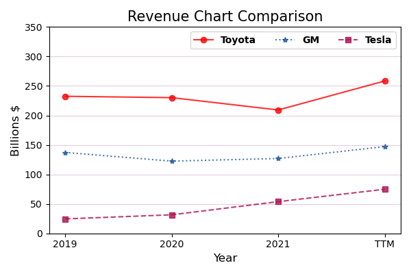

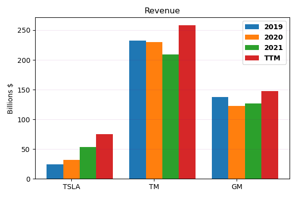

- Tesla's revenue steadily increased every year
- Toyota's revenue decreased from 2019 to 2021. However, TTM data represents that Toyota gains twice the amount of its revenue loss from 2020 to 2021.
- GM graph varys slightly, but fairly consistent.

## Market capitalization & outstanding share numbers

- Market capitalization represents a total value of all of company's shares.
- Outstanding shares represent that how many shares are issued at outstanding, it excludes treasury shares.
- Market capitalization = price per share * outstanding shares
- Stock price as of Jan 31th, 2023
  - TSLA = 173.22
  - TM = 146.67
  - GM = 39.32

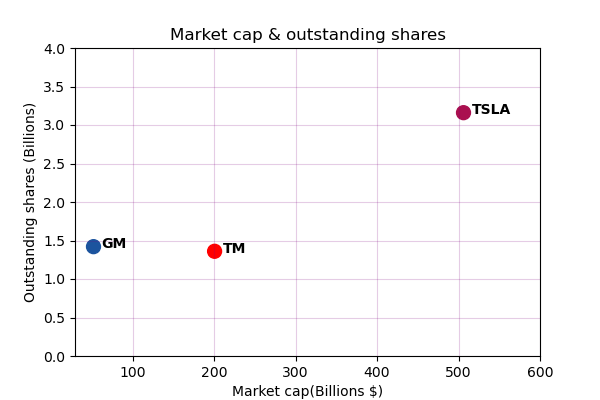

## Gross profit

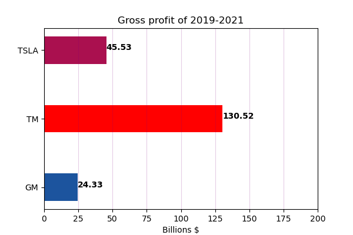

- Toyota is ranked the highest among 3 companies with Gros profit value of \$ 130 Billion, followed by TESLA \\$ 45 Billion and GM \ $24 Billion from 2019 to 2021
- Even though Tesla's market capitalization is almoost 2.5 times higher than Toyota, but its total gross profit of 3 years is 3times lower than Toyota.
- GM's market capitalization is 10times lower than Tesla, but its gross profit is higher than half of Tesla's gross profit

## PE Ratio

- PE Ratio represents price to earnings ratio. It is the ratio of a current company's share price to the company's earnings per share.
- Most stock's PE ratio is between 20 and 25.

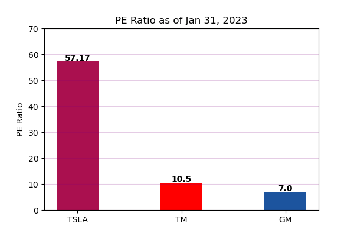

- Tesla's PE ratio is the highest among 3 companies.

## Summary

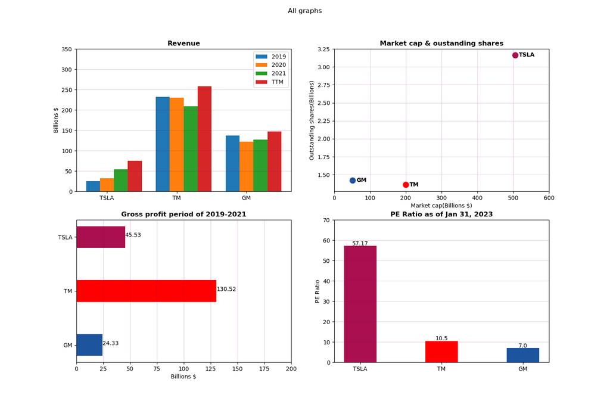

## Brief Data analysis

### - TOYOTA:

- Toyota's revenue shrank from 2019 to 2021, however, TTM revenue pointed high. The Gross profit chart shows that the company is performing very well. With PE Ratio of 10.5, Toyota's stock is traded at great price compare to Tesla. TM's current stock price is 146.67 as of Jan 31,2023.

### - GM:

- GM's revenue is fairly consistant over past three years and TTM. Based on the Market cap & outstanding share chart, GM's market capitalization is the lowest among three companies and about 10 times lower than Tesla. According to Gross profit and Revnue ba chart, GM's revenue is much higher than Tesla, but gross profit stays half of Tesla's. With PE ratio of 7.0, company's value per share is currently sitting the lowest among three companies. GM's current stock price is $ 39.32 as of Jan 31,2023.

# Disclaimer

I am not a financial advisor and this chart is made only for Dohyun Kang's data visualization project.